# Biogenic Habitat Suitability in East Boston

## Introduction

To determine where different major habitat forming species can occur around East Boston, we combined a variety of data layers from MORIS and SWAN model outputs with information on substrate, flow, and depth requirements of different habitat types.

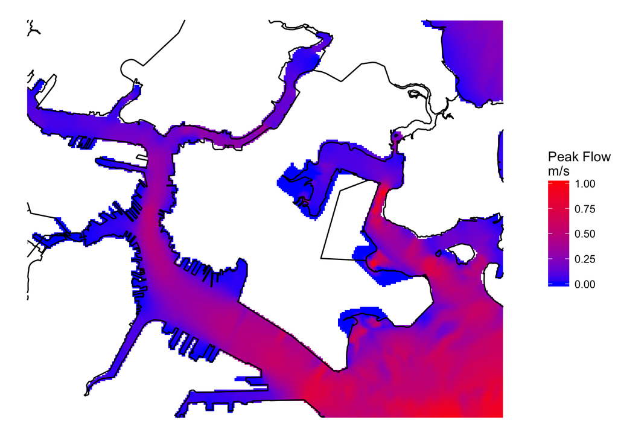

**Predicted Flow Velocities**

Flow and Depth were provided by SWAN model outputs at peak flood tide. Substrate was generated from modeled outputs from the Boston Harbor Barrier project. Briefly, we used current flow, depth, distance from harbor mouth, and distance from shore conditions to classify habitat types provided by MORIS using a random forest model. This resulted in a ~94% classification accuracy. We then applied SWAN model outputs to the model to predict future substrate types.

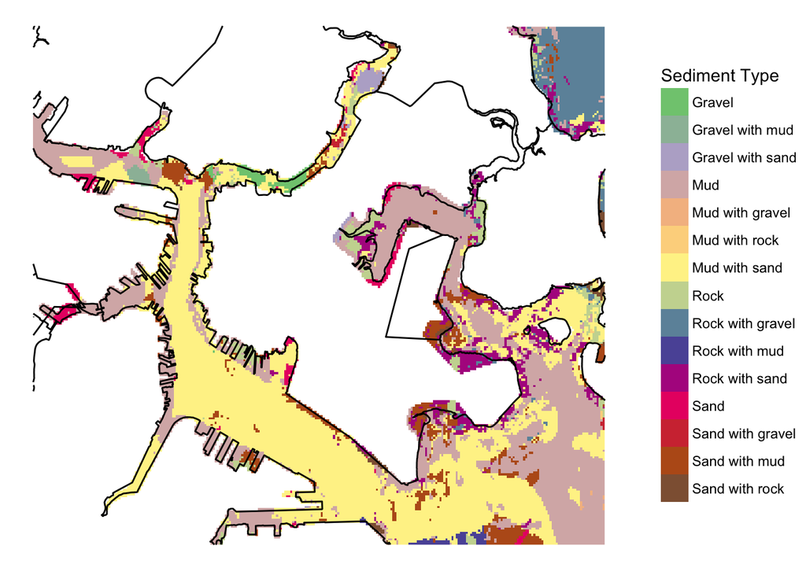

**Predicted Sediment Types**

For our drivers, we sill lack completeness for some species, but, what we have provides good coverage for many species. We still lack a good temperature layer under future conditions, which we need to finish the predictions, but we have a lead on that.

Note, this list also lacks salinity and light/sedimentation. We have that information, but so far model outputs don’t give us relevant information. **This is something to discuss**.

[output not shown]

For Clams, Mussel Beds, Oysters, and Seagrasses, we can put together a potential suitable habitat map noting which of these parameters as well as sediment requirements is matched in the modeled rasters.

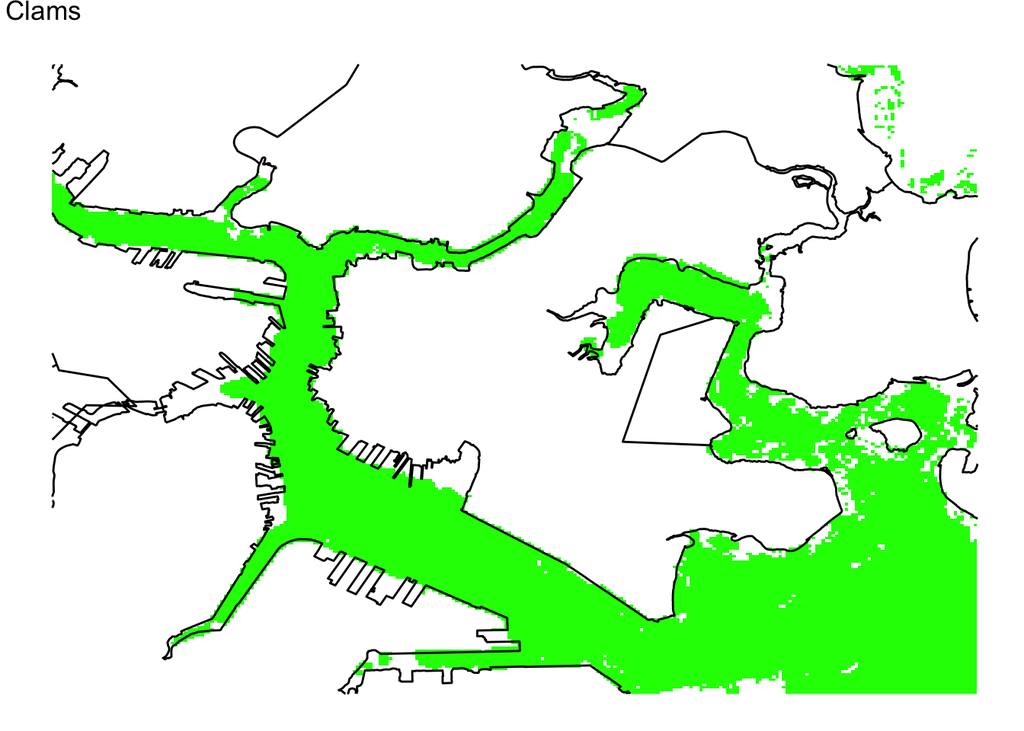

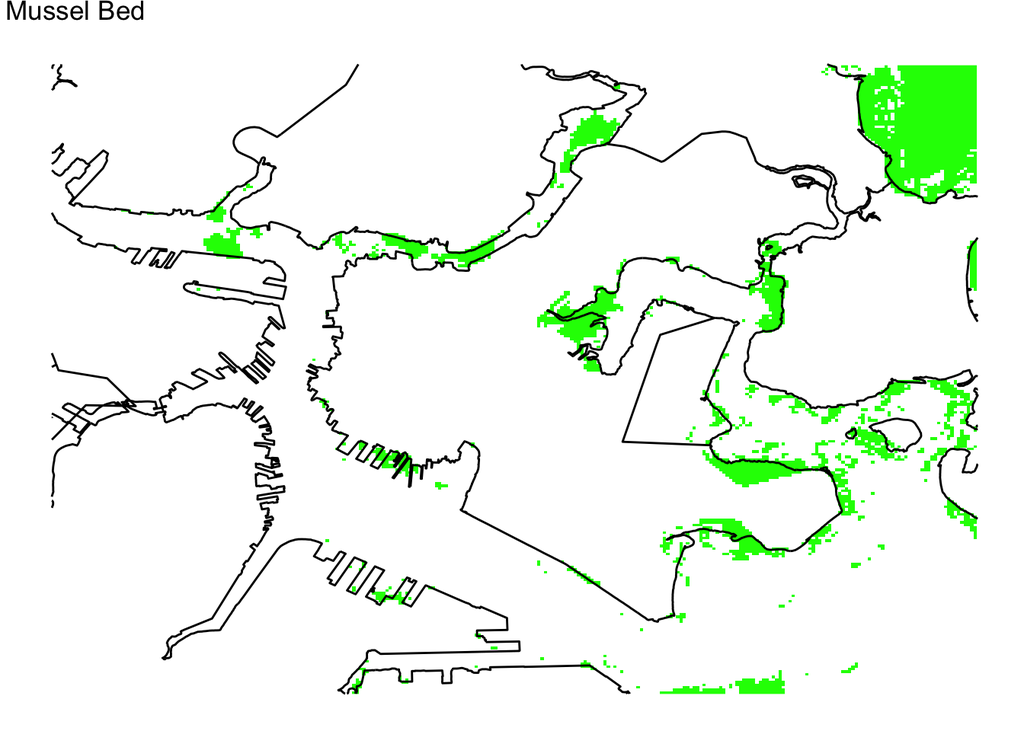

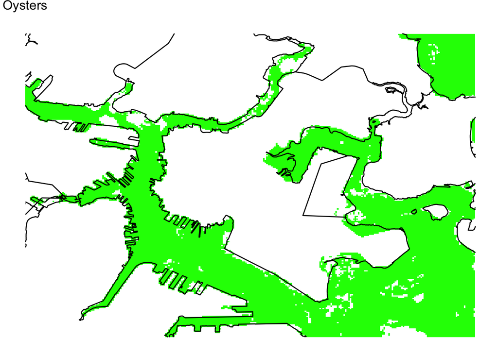

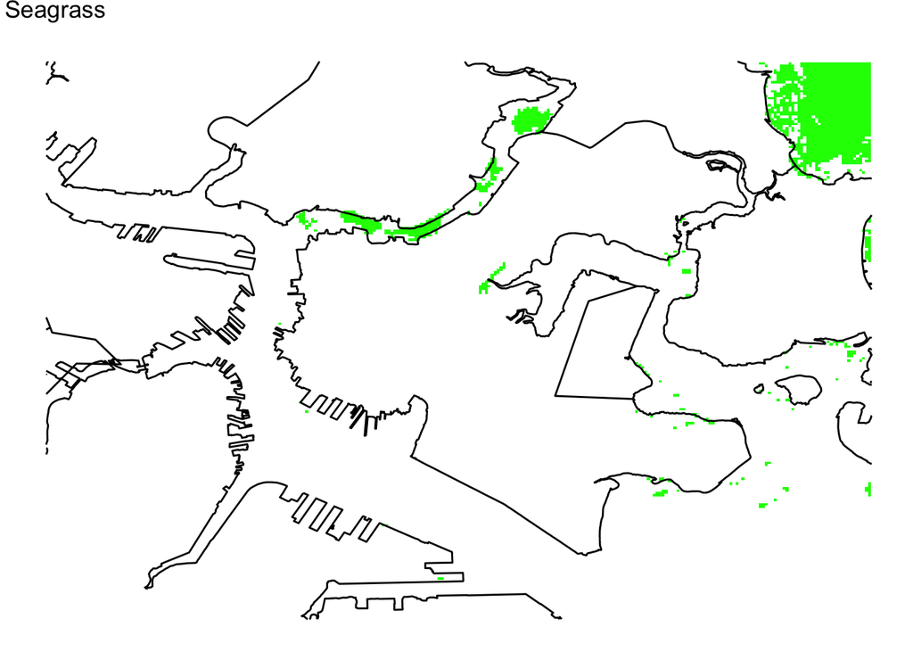